# BIOEE 4751: eBird Status & Trends

Matt Strimas-Mackey & Tom Auer

[eBird Status and Trends](https://ebird.org/science/status-and-trends) links bird sightings from hundreds of thousands of [eBirders](https://ebird.org) with habitat information from satellites to create predictions of the broad scale patterns of distribution and abundance of bird species. These products allow us to explore movements, range boundaries, and the spatiotemporal pattern of abundance for over 600 North American birds across the entire Western Hemisphere at high spatial and temporal resolution. In addition to exploring the various Status and Trends products through the website, the underlying data are available for download and analysis in R.

In this lab, we’ll learn how to access, analyze, and visualize the Status and Trends data within R using the package [`ebirdst`](https://cornelllabofornithology.github.io/ebirdst/). As an example, we’ll focus on the [Baltimore Oriole](https://www.allaboutbirds.org/guide/Baltimore_Oriole/), a familiar songbird that breeds in open woodlands throughout the Northeastern United States. Start by opening the [Status and Trends page for Baltimore Oriole](https://ebird.org/science/status-and-trends/balori) and explore the products that are available, paying particular attention to the weekly abundance animation and the seasonal abundance maps.

Now that you’re familiar with the products available through Status and Trends, let’s dive into the raw data! We’ll start by learning how to download the data, then we’ll produce maps of occurrence and abundance for a given week.

## Setup

Before we dive into the material, there’s some setup that needs to be done to ensure we have all the necessary tools. First, [install R](https://cloud.r-project.org/) and [RStudio](https://rstudio.com/products/rstudio/download/#download), which we’ll be using to interact with R. It’s important to have the most recent versions of both R and RStudio, so if you haven’t installed or updated them within the last 6 months, re-install them now. Next, open RStudio and install the following add on R packages that provide additional functionality not included in base R, you only need to run this line of code once:

```r
install.packages("remotes")
remotes::install_github(c("CornellLabofOrnithology/ebirdst",
                          "ropensci/rnaturalearth",
                          "ropensci/rnaturalearthdata"))
```

To get started with this lab, open up RStudio and create a new project from the File menu. This will create a new directory on your commputer in which will contain your code and data for this project. Create a new R script (File > New File) to contain all the code in this lab and save it in your project directory. Finally, download [this file of GIS data](https://github.com/mstrimas/bioee-4751_ebirdst/raw/master/data/gis-data.gpkg), which contains some contextual gis layers that we’ll use when making maps. Place this file in a `data/` subdirectory of your project.

## Download data

The Status and Trends website is a great resources for exploring patterns of bird movement throughout North America, but if we want to make custom visualizations or perform analyses we’ll need to access the data underlying the Status and Trends products. Fortunately, all this raw data is stored in the cloud on the [Amazon Web Services Registry of Open Data](https://registry.opendata.aws/ebirdst/) and the R package `ebirdst` gives you access to these data. To see a list of all the species available through `ebirdst` you can explore the `ebirdst_runs` data frame. Before doing so, we’ll need to attach the add on R packages that we’ll be using throughout this lab using the `library()` command.

```r
library(raster)
library(sf)
library(dplyr)
library(scales)
library(ebirdst)

glimpse(ebirdst_runs)
```

```
#> Observations: 610
#> Variables: 14
#> $ species_code                    <chr> "bbwduc", "fuwduc", "empgoo", "snogoo…
#> $ run_name                        <chr> "bbwduc-ERD2018-EBIRD_SCIENCE-2019110…
#> $ scientific_name                 <chr> "Dendrocygna autumnalis", "Dendrocygn…
#> $ common_name                     <chr> "Black-bellied Whistling-Duck", "Fulv…
#> $ breeding_start_dt               <date> 2018-05-24, 2018-05-10, 2018-05-24, …
#> $ breeding_end_dt                 <date> 2018-08-03, 2018-08-17, 2018-06-21, …
#> $ nonbreeding_start_dt            <date> 2018-01-18, 2018-11-30, 2018-10-26, …
#> $ nonbreeding_end_dt              <date> 2018-03-01, 2018-02-15, 2018-04-05, …
#> $ postbreeding_migration_start_dt <date> 2018-08-10, 2018-08-24, 2018-06-28, …
#> $ postbreeding_migration_end_dt   <date> 2018-01-11, 2018-11-23, 2018-10-19, …
#> $ prebreeding_migration_start_dt  <date> 2018-03-08, 2018-02-22, 2018-04-12, …
#> $ prebreeding_migration_end_dt    <date> 2018-05-17, 2018-05-03, 2018-05-17, …
#> $ year_round_start_dt             <date> NA, NA, NA, NA, NA, NA, NA, NA, NA, …
#> $ year_round_end_dt               <date> NA, NA, NA, NA, NA, NA, NA, NA, NA, …
```

You can run `View(ebirdst_runs)` to explore this table interacticely within RStudio. The function `ebirdst_download()` downloads data for a single species; all you need to provide is the name of the species.

```r
species <- "Baltimore Oriole"
dl_path <- ebirdst_download(species)
```

The variable `dl_path` now contains the location on your computer where the data were downloaded to. By default, all Status and Trends data are downloaded to a special directory buried within your file system. This is done by design because it’s critical that you don’t change the file structure of the downloaded data package otherwise `ebirdst` won’t be able to work with the data; however, you can use `print(dl_path)` to see where the files are.

Let’s use `list.files()` to see what files were downloaded:

```r
list.files(dl_path, recursive = TRUE)
```

```
#>  [1] "data/balori-ERD2018-EBIRD_SCIENCE-20191025-bb8f7498_config.rds"
#>  [2] "data/balori-ERD2018-EBIRD_SCIENCE-20191025-bb8f7498_srd_raster_template.tif"
#>  [3] "results/tifs/balori-ERD2018-EBIRD_SCIENCE-20191025-bb8f7498_hr_2018_abundance_lower.tif"
#>  [4] "results/tifs/balori-ERD2018-EBIRD_SCIENCE-20191025-bb8f7498_hr_2018_abundance_median.tif"
#>  [5] "results/tifs/balori-ERD2018-EBIRD_SCIENCE-20191025-bb8f7498_hr_2018_abundance_seasonal_breeding.tif"
#>  [6] "results/tifs/balori-ERD2018-EBIRD_SCIENCE-20191025-bb8f7498_hr_2018_abundance_seasonal_nonbreeding.tif"
#>  [7] "results/tifs/balori-ERD2018-EBIRD_SCIENCE-20191025-bb8f7498_hr_2018_abundance_seasonal_postbreeding_migration.tif"
#>  [8] "results/tifs/balori-ERD2018-EBIRD_SCIENCE-20191025-bb8f7498_hr_2018_abundance_seasonal_prebreeding_migration.tif"
#>  [9] "results/tifs/balori-ERD2018-EBIRD_SCIENCE-20191025-bb8f7498_hr_2018_abundance_upper.tif"
#> [10] "results/tifs/balori-ERD2018-EBIRD_SCIENCE-20191025-bb8f7498_hr_2018_count_median.tif"
#> [11] "results/tifs/balori-ERD2018-EBIRD_SCIENCE-20191025-bb8f7498_hr_2018_occurrence_median.tif"
#> [12] "results/tifs/band_dates.csv"
```

Notice that most of these files end in `.tif`. These are GeoTIFFs, which is the most widespread format for storing spatial raster data, i.e. where space is divided up into a regular grid of cells each of which is assigned some quantity such as abundance. The [`ebirdst` website](https://cornelllabofornithology.github.io/ebirdst/articles/ebirdst-introduction.html#raster-layer-description) contains a desciption of what data each of the files contains.

## Loading data into R

Now that we’ve downloaded the Baltimore Oriole data, let’s load some into our R session so we can work with it. The R package `raster` provides tools for working with raster data of the form stored in the GeoTIFFs we just downloaded. The `ebirdst` function `load_raster()` loads one of the GeoTIFFs into an object the `raster` package can work with. For example, to load the weekly abundance and occurrence data, we can use:

```r
occ <- load_raster("occurrence", path = dl_path)
abd <- load_raster("abundance", path = dl_path)
```

The **occurrence** layer represents the expected probability of occurrence of the species, ranging from 0 to 1, on an eBird Traveling Count by a skilled eBirder starting at the optimal time of day with the optimal search duration and distance that maximizes detection of that species in a region. The abundance layer represents the expected relative abundance of Baltimore Orioles on an similarly optimal eBird Traveling Count. The `abd` and `occ` variables store `RasterStack` objects and we can use some functions from the `raster` package to get information about them. Specifically, note that the size of each cell (aka the resolution) is 2.96 km (2,962 m) and that there are 52 layers in each `RasterStack` corresponding to the estimates of abundance and occurrence for each of the 52 weeks of the year.

```r
res(abd)
```

```
#> [1] 2962.807 2962.809
```

```r
nlayers(abd)
```

```
#> [1] 52
```

The `ebirdst` function `parse_raster_dates()` gives us the mid point of the week that each layer in the `RasterStack` corresponds to.

```r
parse_raster_dates(abd)
```

```
#>  [1] "2018-01-04" "2018-01-11" "2018-01-18" "2018-01-25" "2018-02-01"
#>  [6] "2018-02-08" "2018-02-15" "2018-02-22" "2018-03-01" "2018-03-08"
#> [11] "2018-03-15" "2018-03-22" "2018-03-29" "2018-04-05" "2018-04-12"
#> [16] "2018-04-19" "2018-04-26" "2018-05-03" "2018-05-10" "2018-05-17"
#> [21] "2018-05-24" "2018-05-31" "2018-06-07" "2018-06-14" "2018-06-21"
#> [26] "2018-06-28" "2018-07-06" "2018-07-13" "2018-07-20" "2018-07-27"
#> [31] "2018-08-03" "2018-08-10" "2018-08-17" "2018-08-24" "2018-08-31"
#> [36] "2018-09-07" "2018-09-14" "2018-09-21" "2018-09-28" "2018-10-05"
#> [41] "2018-10-12" "2018-10-19" "2018-10-26" "2018-11-02" "2018-11-09"
#> [46] "2018-11-16" "2018-11-23" "2018-11-30" "2018-12-07" "2018-12-14"
#> [51] "2018-12-21" "2018-12-28"
```

When you explored the Status and Trends website you likely saw static [seasonal abundance maps](https://ebird.org/science/status-and-trends/balori/abundance-map) in addition to the animated weekly maps. These seasonal maps are created by taking the average of the weekly layers for all weeks within the given season (e.g. “breeding”), where the date boundaries of the season are defined through a process of expert review. The raw data underlying these seasonal maps is also contained within the downloaded data. Load the seasonal data now with:

```r
abd_seasonal <- load_raster("abundance_seasonal", path = dl_path)
# the season that each layer corresponds to can be accessed with
names(abd_seasonal)
```

```
#> [1] "postbreeding_migration" "prebreeding_migration"  "nonbreeding"
#> [4] "breeding"
```

## Mapping occurrence and abundance

Let’s start by mapping some of these data! We’ll pick a week and produce maps comparing the occurrence and abundance of Baltimore Oriole for this week. For the sake of this example, we’ll choose the week centered on June 14 (week 24), which is during the breeding season for Baltimore Oriole.

```r
# identify which layer our focal week corresponds to
week_date <- as.Date("2018-06-14")
week_index <- which(parse_raster_dates(abd) == week_date)
week_index
```

```
#> [1] 24
```

We can map a quick map of the abundance data using the `plot()` function from the `raster` package.

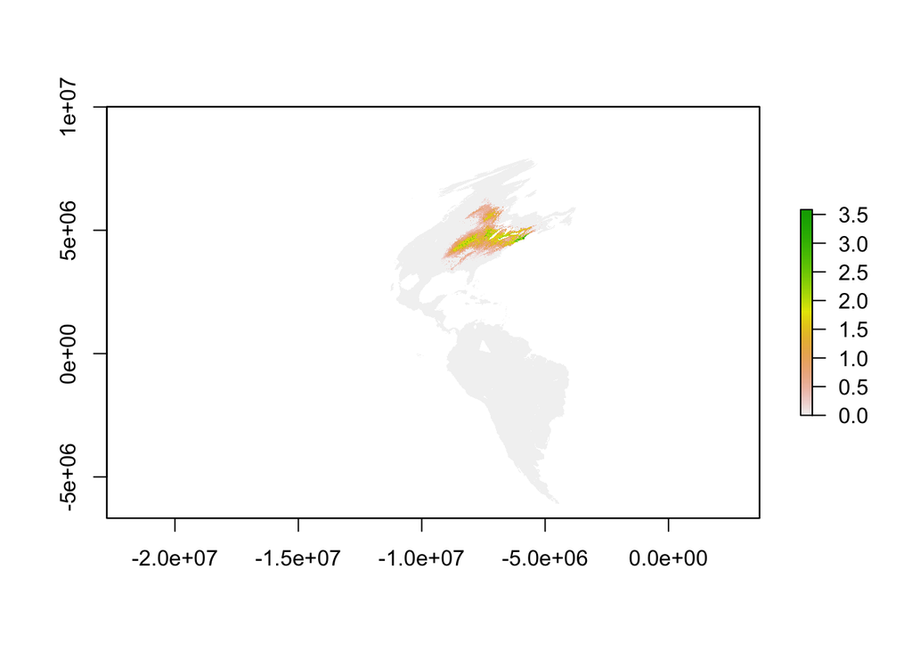

```r
plot(abd[[week_index]])
```

The following code performs these data preparation steps.

```r
# get species-specific map projection and full annual cycle extent
map_pars <- load_fac_map_parameters(dl_path)
proj <- map_pars$custom_projection
fac_ext <- map_pars$fa_extent_sinu

# project the abundance and occurrence data for the given week
# crop to the pre-calculated full annual extent to speed up projection
occ_proj <- occ[[week_index]] %>%
  crop(fac_ext + 5e5) %>%
  projectRaster(crs = proj, method = "ngb")
abd_proj <- abd[[week_index]] %>%
  crop(fac_ext + 5e5) %>%
  projectRaster(crs = proj, method = "ngb")

# determine non-zero extent for the focal week
week_ext <- calc_full_extent(occ_proj)
# generate a spatial polygon of the extent
week_ext_sf <- week_ext %>%
  as("SpatialPolygons") %>%
  st_as_sf() %>%
  st_set_crs(proj) %>%
  st_geometry()

# calculate quantile bins
occ_bins <- calc_bins(occ_proj, method = "quantile")$bins
abd_bins <- calc_bins(abd_proj, method = "quantile")$bins
```

We can now make a much improved version of the map. Note that the below map uses the color palette from the online Status and Trends maps, accessed via `abundance_palette()`, which is much better than the default palette used by `raster`. Again, we’ll only map the abundance data for now.

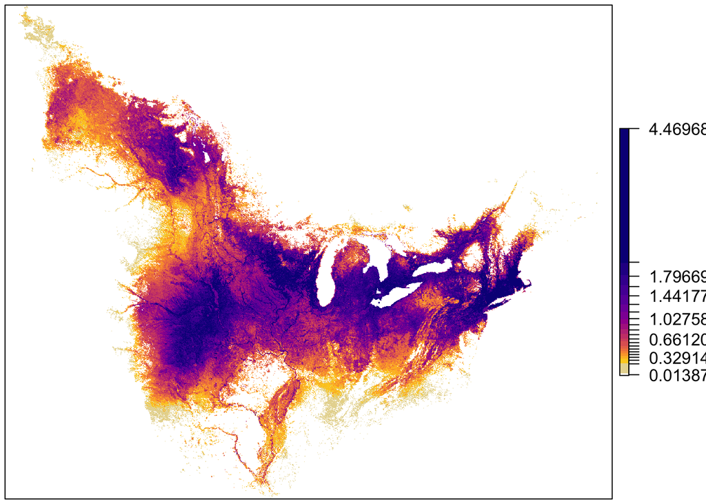

```r
par(mar = c(0.25, 0.25, 0.25, 0.5))
pal <- abundance_palette(n = length(abd_bins) - 1)
plot(abd_proj,
     breaks = abd_bins, col = pal,
     maxpixels = ncell(abd_proj),
     ext = week_ext,
     axes = FALSE)
```

This looks much better, but note that this map only show the relative abundance within areas where Baltimore Orioles are predicted to occur. The Status and Trends models also make predictions for where the species is absent and it will be valuable to also show this information. In addition, the data layers make a distinction between areas where the species is predicted to be absent (cell values of 0) and areas where no prediction was made because there wasn’t enough data to fit the model (cell values of NA). The predicted zeros were hidden in the above map because `abd_bins` starts at the lowest *non-zero* value. We can show these predicted zeros by adding an additional bin to capture zero, which we’ll assign to grey in the color palettes.

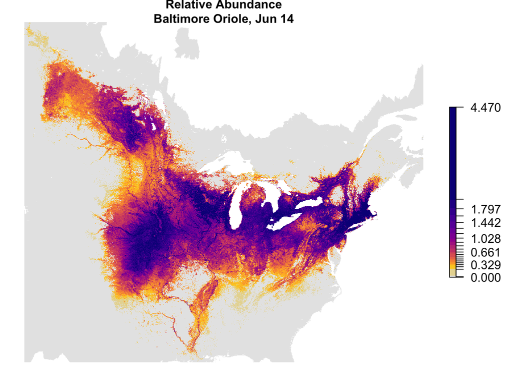

```r
# extend bins
occ_bins_z <- c(0, occ_bins)
abd_bins_z <- c(0, abd_bins)
# add grey to palette
pal_z <- c("#e6e6e6", pal)

# produce map
par(mar = c(0.25, 0.25, 1.5, 0.5))
title <- paste0("Relative Abundance\n", species,
               ", ", format(week_date, "%b %d"))
plot(abd_proj,
     breaks = abd_bins_z, col = pal_z,
     # only show 3 decimals of precision in legend
     lab.breaks = comma(abd_bins_z, 0.001),
     maxpixels = ncell(abd_proj),
     ext = week_ext,
     main = title, cex.main = 1,
     axes = FALSE, box = FALSE)
```

Looks great! The final step is to add some contextual information: state borders, country borders, and a background layer showing the land to show regions where no prediction was made. We can get all these layers from [Natural Earth](https://www.naturalearthdata.com/). These layers can be downloaded with the the R package `rnaturalearth`; however, for this lab we’ve put these [layers in a GeoPackage file](https://github.com/mstrimas/bioee-4751_ebirdst/raw/master/data/gis-data.gpkg) for easy acess. Unlike the Status and Trends data, which is in raster format, these borders are in the form of spatial lines and polygons, which we can work with using the `sf` package in R. Let’s load these data now. If you’re interested in working with spatial data in R, the free online book [Geocomputation with R](https://bookdown.org/robinlovelace/geocompr/) is an excellent resources.

The GIS data are provided for the whole earth and we’ll need to crop them to the non-zero extent prior to transforming them to the species-specific, custom projection.

```r
f_gis <- "data/gis-data.gpkg"
# create a polygon to crop the gis data to
week_ext_ll <- week_ext_sf %>%
  # buffer by 1000 km
  st_buffer(1e6) %>%
  # tranform to lat-lon to match gis layers
  st_transform(crs = 4326)

# western hemisphere land boundary
ne_land <- read_sf(f_gis, "ne_land") %>%
  # crop to non-zero extent
  st_intersection(week_ext_ll) %>%
  # transform to custom projection
  st_transform(crs = proj) %>%
  st_geometry()

# country lines
ne_country_lines <- read_sf(f_gis, "ne_country_lines") %>%
  st_intersection(week_ext_ll) %>%
  st_transform(crs = proj)

# state lines
ne_state_lines <- read_sf(f_gis, "ne_state_lines") %>%
  st_intersection(week_ext_ll) %>%
  st_transform(crs = proj)
```

Now we can make the final maps, building up the different components in layers with multiple calls to `plot()`. At this stage we’ll make occurrence and abundance maps so we can compare them. You’ll notice there’s some additional code below to produce legends, this is necessary because we’re using quantile bins and we just wnat to show the minimum, maximum, and midpoint on the color bar.

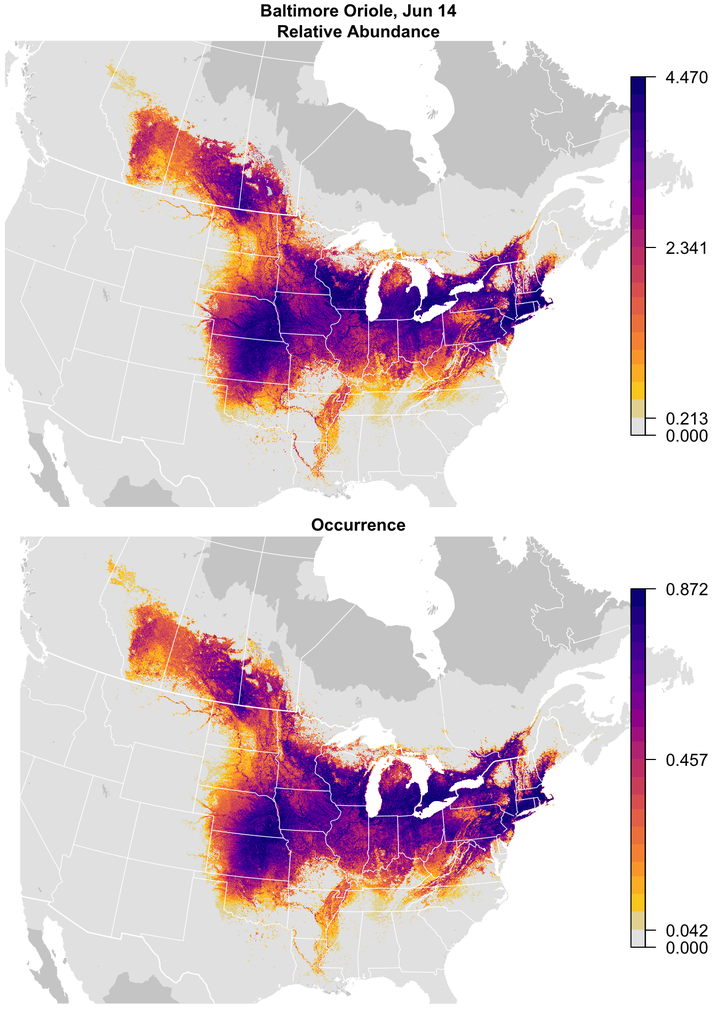

```r
par(mar = c(0.25, 0.25, 2, 0.25), mfrow = c(2, 1))

# abundance map
title <- paste0(species, ", ", format(week_date, "%b %d"), "\n",
                "Relative Abundance")
# add land background/area of no prediction
plot(ne_land, col = "#cfcfcf", border = FALSE,
     main = title, cex.main = 1,
     xlim = c(week_ext@xmin, week_ext@xmax),
     ylim = c(week_ext@ymin, week_ext@ymax))
# add abundance data including predicted zeros
plot(abd_proj,
     breaks = abd_bins_z, col = pal_z,
     maxpixels = ncell(abd_proj),
     legend = FALSE, add = TRUE)
# country and state boundaries
plot(ne_state_lines, col = "white", lwd = 0.7, add = TRUE)
plot(ne_country_lines, col = "white", lwd = 1.2, add = TRUE)
# legend
lbl_brks <- seq(0, max(abd_bins), length.out = length(abd_bins_z))
lbls_at <- c(0, quantile(lbl_brks[-1], c(0, 0.5, 1)))
lbls <- comma(lbls_at, accuracy = 0.001)
plot(abd_proj, legend.only = TRUE,
     breaks = lbl_brks, col = pal_z,
     smallplot = c(0.88, 0.90, 0.15, 0.85),
     axis.args = list(at = lbls_at, labels = lbls))

# occurrence map
# add land background/area of no prediction
plot(ne_land, col = "#cfcfcf", border = FALSE,
     main = "Occurrence", cex.main = 1,
     xlim = c(week_ext@xmin, week_ext@xmax),
     ylim = c(week_ext@ymin, week_ext@ymax))
# add occurrence data including predicted zeros
plot(occ_proj,
     breaks = occ_bins_z, col = pal_z,
     maxpixels = ncell(occ_proj),
     legend = FALSE, add = TRUE)
# country and state boundaries
plot(ne_state_lines, col = "white", lwd = 0.7, add = TRUE)
plot(ne_country_lines, col = "white", lwd = 1.2, add = TRUE)
# legend
lbl_brks <- seq(0, max(occ_bins), length.out = length(occ_bins_z))
lbls_at <- c(0, quantile(lbl_brks[-1], c(0, 0.5, 1)))
lbls <- comma(lbls_at, accuracy = 0.001)
plot(occ_proj, legend.only = TRUE,
     breaks = lbl_brks, col = pal_z,
     smallplot = c(0.88, 0.90, 0.15, 0.85),
     axis.args = list(at = lbls_at, labels = lbls))
```